# Pauta examen estadistica primavera 2019

Ricardo Mayer

29/12/2019

## Instrucciones

1. En RStudio, cree un nuevo R script
2. Guárdelo y nómbrelo de la siguiente manera:
   - `apellido-nombre-estadistica-apellidodelprofesor.R`
   - `perez-juana-estadistica-mayer.R`
3. Escriba sus respuestas en ese script. Cualquier texto o comentario debe ir como comentario de R (i.e. precedido de un #)
4. Antes de terminar, asegúrese de guardar todo su trabajo. No nos haremos responsables si envían una versión incompleta de su trabajo.
5. Al terminar, envíen sus archivos al correo electrónico de su profesor.

## Preguntas

1. (10 puntos) Genere dos muestras de números aleatorios: una proveniente de una distribución normal estándar y otra proveniente de una distribución normal con valor esperado 5 y varianza 9. Cada muestra debe ser de tamaño 1000. Obtenga un histograma para cada muestra.

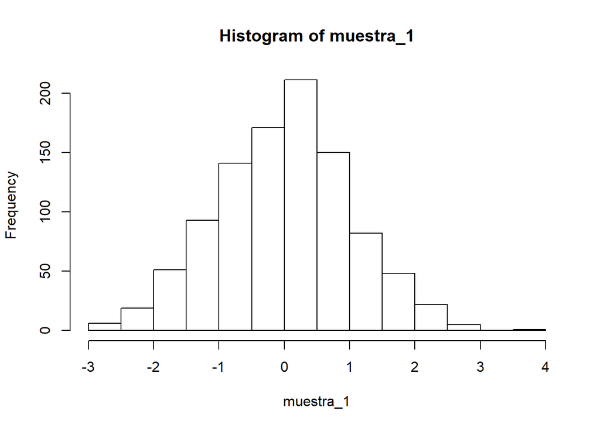

```r
# primera muestra:
muestra_1 <- rnorm(n = 1000)

# segunda muestra: (si la varianza es 9, la desv estandar es 3)
muestra_2 <- rnorm(n = 1000, mean = 5, sd = 3)

# histograma de la primera muestra
# (no haremos cambios a la apariencia, pero si Ud los hace bienvenidos sean)
hist(muestra_1)
```

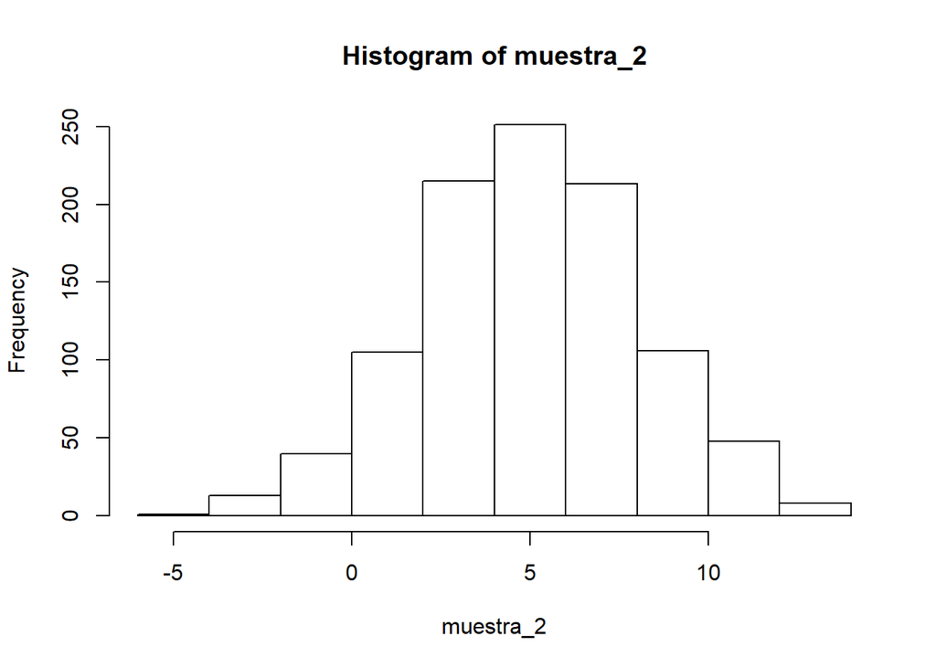

```r
# histograma de la primera muestra
hist(muestra_2)
```

2. (10 puntos) Genere una muestra tamaño 500 con número aleatorios provenientes de una distribución exponencial con valor esperado igual a 20.
   1. 4. Calcule la media de su muestra. Es igual menor o mayor al valor esperado de esta distribución?
   2. 4. Calcule el cuantil 0.33 de su muestra. Es igual, menor o mayor que el cuantil 0.33 de esta distribucion?
   3. 2. Obtenga un gráfico de caja y bigotes (un box plot) de su muestra. Existen valores extremos? Justifique.

```r
muestra_exp <- rexp(n = 500, rate = 1/20)

# 2.a:
media_muestral <- mean(muestra_exp)
media_muestral
```

```
## [1] 18.62255
```

```r
# esta parte la podrían hacer "a mano" pero aquí usaremos la comparacion ">"
es_mayor_q_valor_esperado <- media_muestral > 20

# y el resultado es:
es_mayor_q_valor_esperado
```

```
## [1] FALSE
```

```r
# 2.b:
q33 <- quantile(muestra_exp, probs = 0.33)
q33
```

```
##      33%
## 7.173008
```

```r
# esta parte la podrían hacer "a mano" pero aquí usaremos la comparacion ">"
qexp(0.33, rate = 1/20)
```

```
## [1] 8.009551
```

```r
q33_muestra_mayor_q33_dist<- q33 > qexp(0.33, rate = 1/20)

# y el resultado es:
q33_muestra_mayor_q33_dist
```

```
##   33%
## FALSE
```

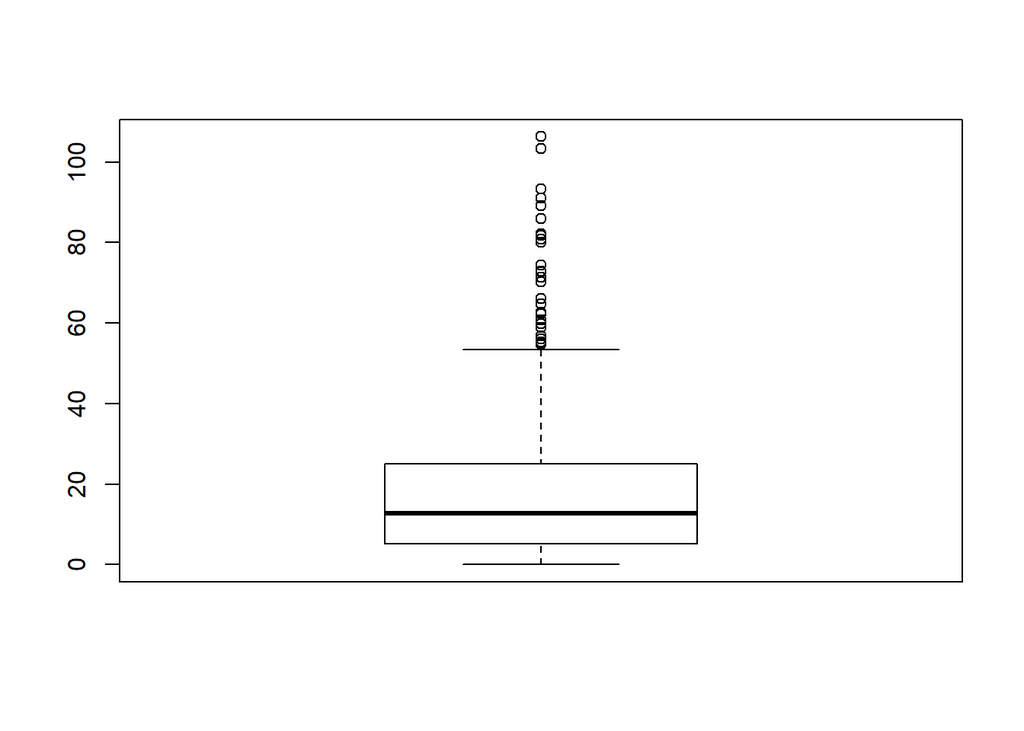

```r
# 2.c:
boxplot(muestra_exp)
```

```r
# En los graficos de caja (o de caja y bigote) los valores extremos son representados
# como puntos más allá de los bigotes. En este grafico se ve claramente que hay valores
# extremos en la parte superior de la distribución, donde los valores son mayores
```